# Exploratory Data Analysis

## Preface

This markdown will illustrate all the process involved for the Exploratory Data Analysis for the data-set that contains the detailed data on the victims of the most catastrophic civil war that Nepal has ever suffered. The data resource that is being used for the process is collected and quantified from the INSEC (Informal Sector Service Center) documentations on victim. a INCSEC is well-known human rights organization working on human rights issues in Nepal since 1988. Victim specific information are available for non-profit use at http://www.insec.org.np/victim/.

## Data Understanding

This segment will load all the required packages that will be used through out the process and will load the dataset from the acquired flat file into the environment. In addition, the preliminary understanding of the data resource will be presented.

```r
# Loading required libraries
if(!require(pacman))install.packages("pacman")

devtools::install_github('bbc/bbplot')

pacman::p_load('tidyverse', 'skimr', 'Hmisc',
               'DataExplorer',  'ggcorrplot',
               'funModeling', 'lubridate', 'scales',
               'grid', 'RColorBrewer', 'bbplot')
```

```r
# Setting up the working directory
setwd('~/Desktop/Sandbox/data-analysis-and-visualisation')

# Removing the variables
remove(list=ls())
```

```r
victims_df <- read_csv('Nepal_Individual_Level_Replication_Data.csv')

view(victims_df)
```

The data set is loaded in the **victims_df** variable. After the data set is loaded we will check if any problem existed while the data was loaded.

```r
problems(victims_df)
```

```
## [1] row      col      expected actual
## <0 rows> (or 0-length row.names)
```

It is clear from the above result that there were no any errors while the data set was loaded. Now we will walk into finding out the number of observations and variables and listing out some records.

```r
glimpse(victims_df)
```

```
## Observations: 15,021
## Variables: 32
## $ sno                      <dbl> 47, 47, 47, 47, 47, 47, 47, 47, 47, 47,…
## $ serialno                 <dbl> 2, 4, 6, 7, 9, 10, 23, 34, 39, 44, 47, …
## $ Computer_FileNO          <dbl> 8614, 2999, 6680, 7158, 2298, 676, 923,…
## $ IncidentDistrict         <chr> "BAGLUNG", "BAGLUNG", "BAGLUNG", "BAGLU…
## $ PermanentDistrict        <dbl> 52, 47, 54, 6, 47, 73, 36, 47, 54, 47, …
## $ year_INC_NEP             <dbl> 2060, 2060, 2061, 2062, 2059, 2058, 205…
## $ age_2                    <dbl> NA, NA, NA, NA, NA, NA, NA, NA, NA, NA,…
## $ Age                      <dbl> 19, 48, 23, 35, 28, 26, 23, 24, 20, 62,…
## $ Year                     <dbl> 2004, 2003, 2005, 2005, 2002, 2002, 200…
## $ Event_Date               <chr> "22/04/2004", "08/12/2003", "21/03/2005…
## $ Region2                  <dbl> 3, 3, 3, 3, 3, 3, 3, 3, 3, 3, 3, 3, 3, …
## $ Region1                  <dbl> 2, 2, 2, 2, 2, 2, 2, 2, 2, 2, 2, 2, 2, …
## $ Mobility                 <dbl> 1, 2, 1, 0, 2, 0, 0, 2, 1, 2, 2, 1, 1, …
```

[output cut: 19 more lines]

From the metrics above, It is clear that the data set has **15,021 rows** and **32 features**.

```r
# Getting the length of the unique entries
victims_df %>%
  map_df(~ n_distinct(.)) %>%
  gather(FEATURE, DISTINCT_ROWS) %>%
  arrange(desc(DISTINCT_ROWS))
```

```
## # A tibble: 32 x 2
##    FEATURE           DISTINCT_ROWS
##    <chr>                     <int>
##  1 serialno                  15021
##  2 Computer_FileNO           10741
##  3 Event_Date                 2587
##  4 Age                          88
##  5 sno                          75
##  6 PermanentDistrict            75
##  7 IncidentDistrict             74
##  8 IncidentVictim               57
##  9 age_2                        54
## 10 LanguageGroup                20
## # … with 22 more rows
```

The content of individual variables are as follows:  
1. sno:  
Numerical district code for IncidentDistrict.  
The numerical code for the district are represented in the following table:

| sno | District | sno | District | sno | District |
| --- | --- | --- | --- | --- | --- |
|  | MANANG | 26 | CHITWAN | 52 | ROLPA |
| 1 | JHAPA | 27 | MAKAWANPUR | 53 | SALYAN |
| 2 | ILAM | 28 | LALITPUR | 54 | RUKUM |
| 3 | PANCHATHAR | 29 | BHAKTAPUR | 55 | BANKE |
| 4 | TAPLEJUNG | 30 | KATHMANDU | 56 | BARDIYA |
| 5 | MORANG | 31 | KAVRE | 57 | SURKHET |
| 6 | SUNSARI | 32 | DHADING | 58 | JAJARKOT |
| 7 | DHANKUTA | 33 | SINDHUPALCHOWK | 59 | DAILEKH |
| 8 | TERATHUM | 34 | NUWAKOT | 60 | DOLPA |
| 9 | BHOJPUR | 35 | RASUWA | 61 | JUMLA |
| 10 | SANKHUWASABHA | 36 | TANAHU | 62 | KALIKOT |
| 11 | SAPTARI | 37 | GORAKHA | 63 | MUGU |
| 12 | SIRAHA | 38 | LAMJUNG | 64 | HUMLA |
| 13 | UDAYAPUR | 39 | SYANGJA | 65 | KAILALI |
| 14 | KHOTANG | 40 | KASKI | 66 | ACHHAM |
| 15 | OKHALDHUNGA | 41 | NAWALPARASI | 67 | DOTI |
| 16 | SOLUKHUMBU | 42 | RUPANDEHI | 68 | BAJURA |
| 17 | DHANUSHA | 43 | PALPA | 69 | BAJHANG |
| 18 | MAHOTTARI | 44 | KAPILVASTU | 70 | KANCHANPUR |
| 19 | SARLAHI | 45 | ARGHAKHANCHI | 71 | DADELDHURA |
| 20 | SINDHULI | 46 | GULMI | 72 | BAITADI |
| 21 | RAMECHHAP | 47 | BAGLUNG | 73 | DARCHULA |
| 22 | DOLAKHA | 48 | PARVAT | 74 | MUSTANG |
| 23 | RAUTAHAT | 49 | MYAGDI |  |  |
| 24 | BARA | 50 | DANG |  |  |
| 25 | PARSA | 51 | PYUTHAN |  |  |

2. serial_no  
   A serial no that starts with numerical value 1.
3. Computer_FileNO  
   INSEC’s computer record of individual victim.
4. IncidentDistrict  
   The district where the incident happened.
5. Age  
   A continuous variable and code age of the victim at the time of incident (if available).
6. incidentdateinnepali  
   All original dates are in Bikram Sambat (B.S.) or Nepali date. This variable identifies Nepali exact date of incident, when available.
7. dateenglish  
   This variable translates the incident date in Nepali to the English date (A.D.).
8. Year  
   Year (in AD) when the incident took place.
9. PermanentDistrict  
   District code sno, for victim’s resident district (permanent district).
10. Region1  
    Geographical Region of Nepal. Nepal has three geographical region.  
    Code 1: if the district comes from Terai (plain) region;  
    Coded 2: if the district comes from hill region;  
    And coded 3: if the district comes from mountainous region.
11. Region2  
    Political region of Nepal. Nepal has five development/political regions.  
    Code 1: if a district is from Eastern Development Region;  
    Coded 2: if a district is from Central Development Region;  
    Coded 3: if a district is from Western Development Region;  
    Coded 4: if the district is from Mid-Western Development Region; and  
    Coded 5: if the district is from Far Western Region.
12. Contiguity  
    If Victim’s permanent district is a neighbor to the district where the event took place, code “1”, otherwise code “0” (Refer Contiguity district list)
13. Contiguity_sno  
    If contiguity is coded “1”, provide contiguous district’’s sno (Refer to district list)
14. Mobility  
    Mobility of a victim depending on permanent district and incident district.  
    Code “0” if the incident took place neither in the permanent district nor in the contiguous district. Code “1” if the incident took place in the contiguous district.  
    Code “2” if the incident took place in the permanent district.
15. IncidentOutcome  
    Incident outcome: either a form of killing, disappearance, or sustained injury  
    Code 1: if the victim is identified as killed  
    Code 2: if the victim is identified as disappeared  
    Code 3: if the victim sustained injury during incident
16. Killed_Type  
    Among those who were identified as killed in above variable, this variable identifies killing types.  
    Code 1: if the Killed incident is classified as “Combat Fighting”  
    Code 2: if the Killed incident is classified as “Extra Judicial Killing”  
    Code 3: if the Killed incident is classified as “Serious Nature”  
    Code 4: if the Killed incident is classified as “Electrocution”  
    Code 5: if the Killed incident is classified as “self-bomb explosion”  
    Code 6: if the killed incident is classified as “bomb explosion”  
    Code 0: if the killed incident is coded as “other”  
    Code 9 : if the incident outcome is not killed.
17. By_State  
    This variable identified whether the state is the perpetrator or not. Code “1” if the state is the perpetrator, otherwise “0”.
18. By_Maoist  
    This variable identified whether the Maoist is the perpetrator or not. Code “1” if the Maoist party is the perpetrator, otherwise “0”.
19. Other_Perpetrators  
    This variable identified other perpetrator when the violence was not targeted either by the State or the Maoist party.  
    Code “1” when other perpetrators are identified, otherwise “0”.
20. Gender  
    Identifies gender of the victim. Code 1: if the victim is identified as female;  
    Code 0 if the victim is identified as male.
21. MaritalStatus  
    Code 1: **Married**  
    Code 2: **Unmarried**  
    Code 3: **Divorced**  
    Code 4: **Widow**  
    Code 5: **Widower**  
    Code 6: **Not clear**
22. LanguageGroup  
    Code 1: **Nepali**  
    Code 2: **Newari**  
    Code 3: **Tamang**  
    Code 4: **Gurung**  
    Code 5: **Tharu**  
    Code 6: **Maithili**  
    Code 7: **Hindi**  
    Code 8: **Awadhi**  
    Code 9: **Bhojpuri**  
    Code 10: **Magar**  
    Code 11: **Chepang**  
    Code 12: **Rai**  
    Code 13: **Thakali**  
    Code 14: **Dhimal**  
    Code 15: **Dotali**  
    Code 16: **Muslim**  
    Code 17: **Thami**  
    Code 18: **Jirel**  
    Code 19: **Other**  
    Code 20: **Not clear**
23. CasteGroup  
    Code 1: **Bramin/Chettri**  
    Code 2: **Janajati**  
    Code 3: **Aadibashi**  
    Code 4: **Madeshi**  
    Code 5: **Dalit**  
    Code 6: **Muslim**  
    Code 7: **“clear” or “mentioned”**  
    Code 9: **“Other”**
24. Partyaffiliation  
    Code 1: Nepali Congress (Democratic)  
    Code 2: Nepali Congress (including its sister organizations and student wing)  
    Code 3: Communist Party Nepal- United Marxist Leninists (CPN-UML) including its sister organization and student wing (i.e. Akhil Nepal Shikshak Sang)  
    Code 4: Communist Party Nepal-Marxist Leninist (CPN-ML)  
    Code 5: United Maoist (REBEL PARTY including its student wing, sister organizations and fronts i.e. Akhil Krantikari)  
    Code 6: People’s Front- Nepal  
    Code 7: Rastriya Prajatantrik Party (RPP)  
    Code 8: Nepal Sadbhawana Party  
    Code 9: United People’s Front  
    Code 10: Nepal Workers and Peasants Party  
    Code 11: Nepal Communist Party-United  
    Code 12: National People’s Liberation Party  
    Code 13: Limbuwan National Liberation Front  
    Code 99: Party Affiliation not identified or not affiliated.
25. EconomicStatus  
    Code 1: **Higher** economic background  
    Code 2: **Middle** economic background  
    Code 3: **Lower-Middle** economic background  
    Code 4: **Lower** economic background  
    Code 5: **Not clear**
26. Education  
    Code 1: **Master’s Degree**  
    Code 2: **Bachelor’s Degree**  
    Code 3: **Intermediate**  
    Code 4: **High School**  
    Code 5: **Lower High School**  
    Code 6: **Primary School**  
    Code 7: **Literate**  
    Code 8: **Illiterate**  
    Code 9: **Not clear**
27. OccupationCategory  
    Code 1: **Agriculture**  
    Code 2: **Wage Laborer**  
    Code 3: **Employed**  
    Code 4: **Teacher**  
    Code 5: **Police**  
    Code 6: **Army**  
    Code 7: **Lawyer**  
    Code 8: **Doctor**  
    Code 9: **Politician**  
    Code 10: **Social worker**  
    Code 11: **Rights activists**  
    Code 12: **Musician**  
    Code 13: **Player**  
    Code 14: **Driver**  
    Code 15: **Student**  
    Code 16: **Journalist**  
    Code 17: **Businessman**  
    Code 18: **Ex-security personnel**  
    Code 19: **other or not clear**
28. Informer  
    Code 1: if the victim was identified or alleged to be an informer mobilized by the state or the Maoist rebel group.  
    Code 0: everything else.
29. LivelihoodDependence  
    Livelihood bases of victim’s dependent  
    Code 1: if dependent’s livelihood support base if agriculture  
    Code 2: if dependent’s livelihood support base is identified other than agriculture  
    Code 3: if dependent’s livelihood support base is identified as “unknown”
30. Compensation  
    Government gave certain amount of money to certain victims as compensation. This process continued well until 2010. Therefore, this particular data should be regarded incomplete.  
    Code 1: if conflict victims received compensation  
    Code 0: if conflict victims did not receive compensation
31. Displacement  
    If this incident had a displacement impact on victim  
    Code 1: if displacement was recorded  
    Code 0: if the displacement was not recorded
32. DisplacementResettlement  
    If displacement was recorded  
    Code 1: if victim was resettled  
    Code 0: if victim was not resettled
33. IncidentVictim  
    If more than one victim was identified as killed in the incident, how many were involved in the incident? This is a continuous measure. If exact number not available, code -99. If the incident had only one victim killed, code -88.

```r
df_status(victims_df)
```

```
##                    variable q_zeros p_zeros  q_na  p_na q_inf p_inf
## 1                       sno       1    0.01     3  0.02     0     0
## 2                  serialno       0    0.00     0  0.00     0     0
## 3           Computer_FileNO       0    0.00     0  0.00     0     0
## 4          IncidentDistrict       0    0.00     0  0.00     0     0
## 5         PermanentDistrict       1    0.01     0  0.00     0     0
## 6              year_INC_NEP       0    0.00   131  0.87     0     0
## 7                     age_2     153    1.02 14552 96.88     0     0
## 8                       Age       0    0.00   310  2.06     0     0
## 9                      Year       0    0.00    39  0.26     0     0
## 10               Event_Date       0    0.00    32  0.21     0     0
## 11                  Region2       0    0.00     0  0.00     0     0
## 12                  Region1       0    0.00     0  0.00     0     0
## 13                 Mobility    4080   27.16     0  0.00     0     0
## 14          IncidentOutcome       0    0.00     1  0.01     0     0
```

[output cut: 51 more lines]

The metrics from above table is presented down below:  
1. **q_zeros** represents the quantities of the zero values present in the variable.  
2. **p_zeros** represents the presence of zero values in percentage.  
3. **q_na** represents the quantity of NA values.  
4. **p_na** represents the presence of NA values in percentage.  
5. **type** represents the data type of the feature: **factor** or **numeric**.  
6. **unique** represents the cardinality of the variable.

From the above metrics table, It is known that features : **age_2**, **Informer** contains maximum number of *NA* values. Hence we will remove these variables for further analysis purpose.

```r
# Removing age_2 and Informer feature from the dataset
victims_df = subset(victims_df, select = -c(age_2, Informer))
```

## Data Validation, Data Quality and Imputation

This segment will deal with lion’s share of the work for any data analysis task of diagnosing the acquired data and deal with any of the problem with the data resource.

```r
# Checking the number of NA record
victims_df %>%
  map_df(~ sum(is.na(.)))
```

```
## # A tibble: 1 x 30
##     sno serialno Computer_FileNO IncidentDistrict PermanentDistri…
##   <int>    <int>           <int>            <int>            <int>
## 1     3        0               0                0                0
## # … with 25 more variables: year_INC_NEP <int>, Age <int>, Year <int>,
## #   Event_Date <int>, Region2 <int>, Region1 <int>, Mobility <int>,
## #   IncidentOutcome <int>, Killed_Type <int>, By_State <int>,
## #   By_Maoist <int>, Other_Perpetrators <int>, Gender <int>,
## #   MaritalStatus <int>, LanguageGroup <int>, CasteGroup <int>,
## #   Partyaffiliation <int>, EconomicStatus <int>, Education <int>,
## #   OccupationCategory <int>, LivelihoodDependence <int>,
## #   Compensation <int>, Displacement <int>,
## #   DisplacementResettlement <int>, IncidentVictim <int>
```

```r
# Changing empty string to NA
victims_df <- victims_df %>%
  na_if("")

# Changing the data types of Event_Date feature to date type
victims_df$Event_Date <- dmy(victims_df$Event_Date)
```

Since the **Year** variable has more significance for further analysis and the the presence of NA value is **0.26% (minimum)**, we will try to capture the value for the **Year** variable from the **Event_Date** variable if the value is present in the **Event_Date** variable and if the data is NA for **Event_Date** we will assign the most frequent value among the **Year** value to the missing **Year** variable data.

```r
# Counting the number of observation with NA value in Year Variable
count(filter(victims_df, is.na(Year)))
```

```
## # A tibble: 1 x 1
##       n
##   <int>
## 1    39
```

```r
# Getting the values from Event_Date where Year variable is NA
victims_df$Year <- ifelse(is.na(victims_df$Year) & !is.na(victims_df$Event_Date), year(victims_df$Event_Date), victims_df$Year)

count(filter(victims_df, is.na(Year)))
```

```
## # A tibble: 1 x 1
##       n
##   <int>
## 1    32
```

From the code execution above, we were successful to fill the 7 observation of **Year** variable with the year value from **Event_Date**. Since the number of **NA** values present in the **Year** variable is **32 (very minimum)** and we don’t want to loose the information of those 32 observation we have opted for **Mode Imputation**.

```r
# Changing NA values to mode values in Year variable
year_unique_value <- unique(victims_df$Year[!is.na(victims_df$Year)])

# Calculating most frequent value of Year variable
year_mode_value <- year_unique_value[which.max(tabulate(match(victims_df$Year, year_unique_value)))]

victims_df$Year[is.na(victims_df$Year)] <- year_mode_value
```

```r
# Counting the number of NA values in Age variable
count(filter(victims_df, is.na(Age)))
```

```
## # A tibble: 1 x 1
##       n
##   <int>
## 1   310
```

From the code execution above, It is clear that we have **310 observations** where the value for **Age** variable is missing. Since every observation in our case is very significant, we don’t want to loose any observation. Hence we will use the **Mean Imputation** for the **Age** variable.

```r
# Changing the NA values in Age variable with Mean of the Age
victims_df <- victims_df %>%
  mutate(Age = as.numeric(Age)) %>%
  transform(victims_df, Age = ifelse(is.na(Age), round(mean(victims_df$Age, na.rm = TRUE)), Age))
```

```r
# Checking the distribution of Age variable
with(victims_df, table(Age))
```

```
## Age
##   1   2   3   4   5   6   7   8   9  10  11  12  13  14  15  16  17  18
##   7  12  10  16  14  21  12  23  25  28  24  41  78 138 180 303 450 696
##  19  20  21  22  23  24  25  26  27  28  29  30  31  32  33  34  35  36
## 814 907 878 849 734 722 632 537 467 760 357 422 322 375 317 306 337 280
##  37  38  39  40  41  42  43  44  45  46  47  48  49  50  51  52  53  54
## 222 197 165 223 186 171 119 112 169 121 107 103 103 124  85  90  84  70
##  55  56  57  58  59  60  61  62  63  64  65  66  67  68  69  70  71  72
##  71  52  34  49  39  35  20  17  22  16  24  14  14  10   3  10   5   8
##  73  74  75  76  77  78  79  80  82  83  84  87  89  90  94
##   2   5   3   3   2   1   2   4   2   1   3   1   1   2   1
```

Lastly, we will use mode imputation for all the label encoded variables with the mode values as there are very less number of NA values in the label encoded categorical variables.

```r
# Changing NA values to mode values in IncidentOutcome variable
IncidentOutcome_unique_value <- unique(victims_df$IncidentOutcome[!is.na(victims_df$IncidentOutcome)])

# Calculating most frequent value of IncidentOutcome variable
IncidentOutcome_mode_value <- IncidentOutcome_unique_value[which.max(tabulate(match(victims_df$IncidentOutcome, IncidentOutcome_unique_value)))]

# Replacing the NA value with the mode value
victims_df$IncidentOutcome[is.na(victims_df$IncidentOutcome)] <- IncidentOutcome_mode_value

# Changing NA values to mode values in Killed_Type variable
Killed_Type_unique_value <- unique(victims_df$Killed_Type[!is.na(victims_df$Killed_Type)])

# Calculating most frequent value of Killed_Type variable
Killed_Type_mode_value <- Killed_Type_unique_value[which.max(tabulate(match(victims_df$Killed_Type, Killed_Type_unique_value)))]

# Replacing the NA value with the mode value
victims_df$Killed_Type[is.na(victims_df$Killed_Type)] <- Killed_Type_mode_value


# Changing NA values to mode values in MaritalStatus variable
MaritalStatus_unique_value <- unique(victims_df$MaritalStatus[!is.na(victims_df$MaritalStatus)])

# Calculating most frequent value of MaritalStatus variable
MaritalStatus_mode_value <- MaritalStatus_unique_value[which.max(tabulate(match(victims_df$MaritalStatus, MaritalStatus_unique_value)))]

# Replacing the NA value with the mode value
victims_df$MaritalStatus[is.na(victims_df$MaritalStatus)] <- MaritalStatus_mode_value

# Changing NA values to mode values in LanguageGroup variable
LanguageGroup_unique_value <- unique(victims_df$LanguageGroup[!is.na(victims_df$LanguageGroup)])

# Calculating most frequent value of LanguageGroup variable
LanguageGroup_mode_value <- LanguageGroup_unique_value[which.max(tabulate(match(victims_df$LanguageGroup, LanguageGroup_unique_value)))]

# Replacing the NA value with the mode value
victims_df$LanguageGroup[is.na(victims_df$LanguageGroup)] <- LanguageGroup_mode_value

# Changing NA values to mode values in CasteGroup variable
CasteGroup_unique_value <- unique(victims_df$CasteGroup[!is.na(victims_df$CasteGroup)])

# Calculating most frequent value of CasteGroup variable
CasteGroup_mode_value <- CasteGroup_unique_value[which.max(tabulate(match(victims_df$CasteGroup, CasteGroup_unique_value)))]

# Replacing the NA value with the mode value
victims_df$CasteGroup[is.na(victims_df$CasteGroup)] <- CasteGroup_mode_value

# Replacing the NA value with the mode value
victims_df$LanguageGroup[is.na(victims_df$LanguageGroup)] <- LanguageGroup_mode_value

# Changing NA values to mode values in Partyaffiliation variable
Partyaffiliation_unique_value <- unique(victims_df$Partyaffiliation[!is.na(victims_df$Partyaffiliation)])

# Calculating most frequent value of Partyaffiliation variable
Partyaffiliation_mode_value <- Partyaffiliation_unique_value[which.max(tabulate(match(victims_df$Partyaffiliation, Partyaffiliation_unique_value)))]

# Replacing the NA value with the mode value
victims_df$Partyaffiliation[is.na(victims_df$Partyaffiliation)] <- Partyaffiliation_mode_value


# Changing NA values to mode values in EconomicStatus variable
EconomicStatus_unique_value <- unique(victims_df$EconomicStatus[!is.na(victims_df$EconomicStatus)])

# Calculating most frequent value of EconomicStatus variable
EconomicStatus_mode_value <- EconomicStatus_unique_value[which.max(tabulate(match(victims_df$EconomicStatus, EconomicStatus_unique_value)))]

# Replacing the NA value with the mode value
victims_df$EconomicStatus[is.na(victims_df$EconomicStatus)] <- EconomicStatus_mode_value


# Changing NA values to mode values in Education variable
Education_unique_value <- unique(victims_df$Education[!is.na(victims_df$Education)])

# Calculating most frequent value of Education variable
Education_mode_value <- Education_unique_value[which.max(tabulate(match(victims_df$Education, Education_unique_value)))]

# Replacing the NA value with the mode value
victims_df$Education[is.na(victims_df$Education)] <- Education_mode_value

# Changing NA values to mode values in OccupationCategory variable
OccupationCategory_unique_value <- unique(victims_df$OccupationCategory[!is.na(victims_df$OccupationCategory)])

# Calculating most frequent value of OccupationCategory variable
OccupationCategory_mode_value <- OccupationCategory_unique_value[which.max(tabulate(match(victims_df$OccupationCategory, OccupationCategory_unique_value)))]

# Replacing the NA value with the mode value
victims_df$OccupationCategory[is.na(victims_df$OccupationCategory)] <- OccupationCategory_mode_value

# Changing NA values to mode values in LivelihoodDependence variable
LivelihoodDependence_unique_value <- unique(victims_df$LivelihoodDependence[!is.na(victims_df$LivelihoodDependence)])

# Calculating most frequent value of LivelihoodDependence variable
LivelihoodDependence_mode_value <- LivelihoodDependence_unique_value[which.max(tabulate(match(victims_df$LivelihoodDependence, LivelihoodDependence_unique_value)))]

# Replacing the NA value with the mode value
victims_df$LivelihoodDependence[is.na(victims_df$LivelihoodDependence)] <- LivelihoodDependence_mode_value


# Changing NA values to mode values in Displacement variable
Displacement_unique_value <- unique(victims_df$Displacement[!is.na(victims_df$Displacement)])

# Calculating most frequent value of Displacement variable
Displacement_mode_value <- Displacement_unique_value[which.max(tabulate(match(victims_df$Displacement, Displacement_unique_value)))]

# Replacing the NA value with the mode value
victims_df$Displacement[is.na(victims_df$Displacement)] <- Displacement_mode_value

# Changing NA values to mode values in DisplacementResettlement variable
DisplacementResettlement_unique_value <- unique(victims_df$DisplacementResettlement[!is.na(victims_df$DisplacementResettlement)])

# Calculating most frequent value of DisplacementResettlement variable
DisplacementResettlement_mode_value <- DisplacementResettlement_unique_value[which.max(tabulate(match(victims_df$DisplacementResettlement, DisplacementResettlement_unique_value)))]

# Replacing the NA value with the mode value
victims_df$DisplacementResettlement[is.na(victims_df$DisplacementResettlement)] <- DisplacementResettlement_mode_value

# Changing NA values to mode values in Gender variable
Gender_unique_value <- unique(victims_df$Gender[!is.na(victims_df$Gender)])

# Calculating most frequent value of Gender variable
Gender_mode_value <- Gender_unique_value[which.max(tabulate(match(victims_df$Gender, Gender_unique_value)))]

# Replacing the NA value with the mode value
victims_df$Gender[is.na(victims_df$Gender)] <- Gender_mode_value

# Changing NA values to mode values in Compensation variable
Compensation_unique_value <- unique(victims_df$Compensation[!is.na(victims_df$Compensation)])

# Calculating most frequent value of Gender variable
Compensation_mode_value <- Compensation_unique_value[which.max(tabulate(match(victims_df$Compensation, Compensation_unique_value)))]

# Replacing the NA value with the mode value
victims_df$Compensation[is.na(victims_df$Compensation)] <- Compensation_mode_value
```

```r
# Checking the number of NA record
victims_df %>%
  map_df(~ sum(is.na(.)))
```

```
## # A tibble: 1 x 60
##     sno serialno Computer_FileNO IncidentDistrict PermanentDistri…
##   <int>    <int>           <int>            <int>            <int>
## 1     3        0               0                0                0
## # … with 55 more variables: year_INC_NEP <int>, Age <int>, Year <int>,
## #   Event_Date <int>, Region2 <int>, Region1 <int>, Mobility <int>,
## #   IncidentOutcome <int>, Killed_Type <int>, By_State <int>,
## #   By_Maoist <int>, Other_Perpetrators <int>, Gender <int>,
## #   MaritalStatus <int>, LanguageGroup <int>, CasteGroup <int>,
## #   Partyaffiliation <int>, EconomicStatus <int>, Education <int>,
## #   OccupationCategory <int>, LivelihoodDependence <int>,
## #   Compensation <int>, Displacement <int>,
## #   DisplacementResettlement <int>, IncidentVictim <int>, sno.1 <int>,
## #   serialno.1 <int>, Computer_FileNO.1 <int>, IncidentDistrict.1 <int>,
## #   PermanentDistrict.1 <int>, year_INC_NEP.1 <int>, Age.1 <int>,
## #   Year.1 <int>, Event_Date.1 <int>, Region2.1 <int>, Region1.1 <int>,
## #   Mobility.1 <int>, IncidentOutcome.1 <int>, Killed_Type.1 <int>,
## #   By_State.1 <int>, By_Maoist.1 <int>, Other_Perpetrators.1 <int>,
## #   Gender.1 <int>, MaritalStatus.1 <int>, LanguageGroup.1 <int>,
## #   CasteGroup.1 <int>, Partyaffiliation.1 <int>, EconomicStatus.1 <int>,
## #   Education.1 <int>, OccupationCategory.1 <int>,
## #   LivelihoodDependence.1 <int>, Compensation.1 <int>,
## #   Displacement.1 <int>, DisplacementResettlement.1 <int>,
## #   IncidentVictim.1 <int>
```

## Data Profiling

In this section, we will walk through various ways to better understand the data resource by calculating the measures of central tendencies, performing statistical analysis to characterize the symmetric distribution of the data, calculating and visualising correlation between the variables.

```r
# Summary matrix for numerical features
victims_df %>%
  select(Age) %>%
  skim()
```

Data summary

| Name | Piped data |
| --- | --- |
| Number of rows | 15021 |
| Number of columns | 1 |
| _______________________ |  |
| Column type frequency: |  |
| numeric | 1 |
| ________________________ |  |
| Group variables | None |

**Variable type: numeric**

| skim_variable | n_missing | complete_rate | mean | sd | p0 | p25 | p50 | p75 | p100 | hist |
| --- | --- | --- | --- | --- | --- | --- | --- | --- | --- | --- |
| Age | 0 | 1 | 28.34 | 11.16 | 1 | 20 | 25 | 34 | 94 | ▂▇▂▁▁ |

From the metrics above, It is clear that the age of the victims range from **1 - 94** and mean age of the victims is **28.3**.

## Data Visualisation

One of the best but yet more challenging way to gain insights on the data is to visualise them: that way we can all the more effectively identify patterns, grasp difficult concepts and draw the attention to the key elements. This segment will try to gain the qualitative understanding of the data by placing it in a visual context so that the systematic patterns, trends, correlations, corrupt data, and outliers that might not otherwise be detected can be unlocked properly.

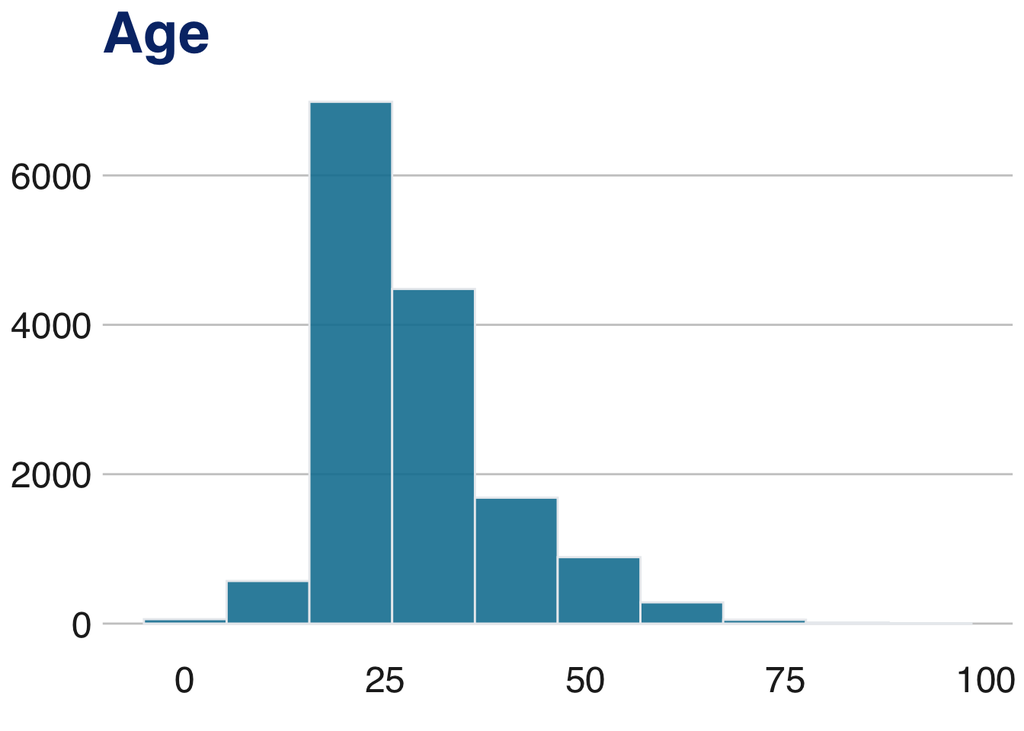

```r
# Histogram Plot for Age Variable
ggplot(victims_df)  +
  geom_histogram(mapping = aes(x=Age), fill="#1380A1", color="#e9ecef", alpha=0.9, bins=10) +     labs(title = "Age") + bbc_style() +
  theme(plot.title = element_text(color = "#063376"))
```

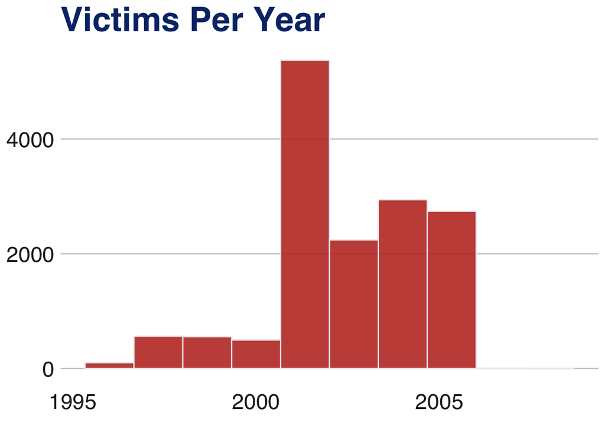

```r
# Histogram Plot for Number of victims per year
ggplot(victims_df)  +
  geom_histogram(mapping = aes(x=Year), fill="#c0392b", color="#e9ecef", alpha=0.9, bins=10) +     labs(title = "Victims Per Year") + bbc_style() +
  theme(plot.title = element_text(color = "#063376"))
```

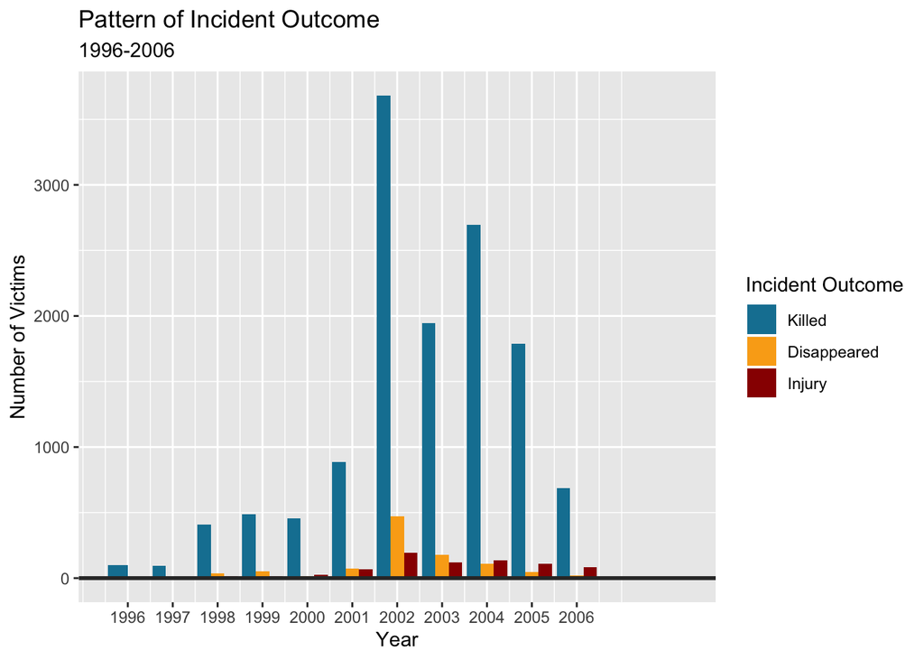

```r
 ggplot(victims_df, aes(x = Year, fill = as.factor(IncidentOutcome))) +
  geom_bar(stat="count", position="dodge") +
  geom_hline(yintercept = 0, size = 1, colour="#333333") +
  scale_fill_manual(values = c("#1380A1", "#FAAB18", "#990000"),
                    name="Incident Outcome",
                    breaks=c(1, 2, 3),
                    labels=c("Killed", "Disappeared", "Injury")) +
  labs(title="Pattern of Incident Outcome", subtitle = "1996-2006") +
  scale_x_continuous(breaks = seq(from = 1996, to = 2006, by = 1)) +
  ylab('Number of Victims')
```

From the grouped bar chart above, It is much clear that the there were maximum number of **Killed** outcomes than **Disappeared** and **Injury**. Also, It can be depicted that the maximum number of casualties were in **2002**.

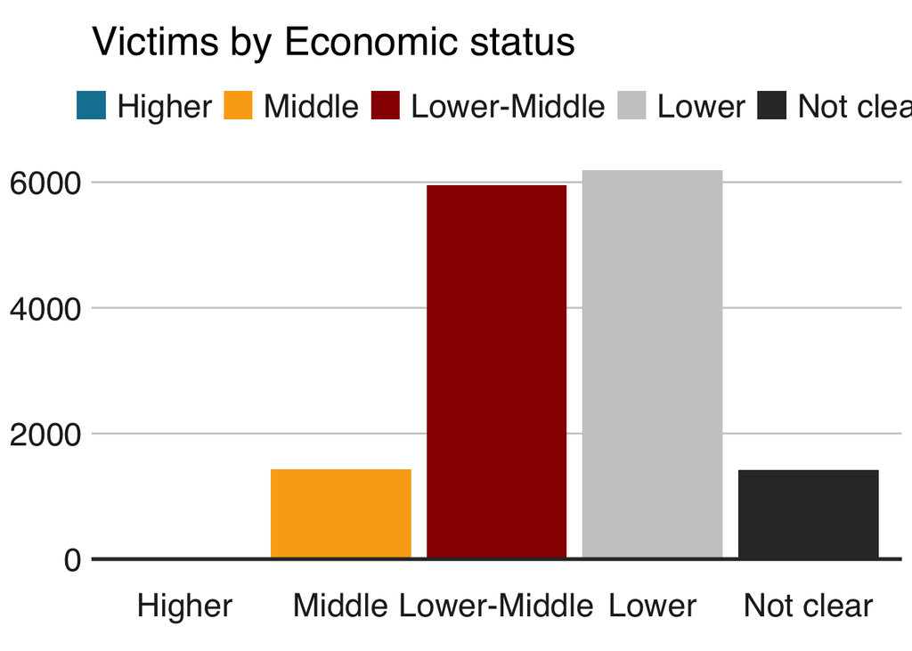

```r
EconomicStatusLabels <- c("Higher", "Middle", "Lower-Middle", "Lower", "Not clear")
# Bar Chart for plotting the number of victims as of Economic Status
 ggplot(victims_df, aes(x = factor(EconomicStatus), fill = factor(EconomicStatus))) +
  geom_bar(stat="count", position="dodge") +
  geom_hline(yintercept = 0, size = 1, colour="#333333") +
  bbc_style() +
  scale_fill_manual(values = c("#1380A1", "#FAAB18", "#990000", "#cbcbcb","#333333"),
                    name="Economic Status",
                    breaks=c(1, 2, 3, 4, 5),
                    labels=EconomicStatusLabels) +
  labs(subtitle="Victims by Economic status") +
  scale_x_discrete(labels = EconomicStatusLabels)
```

From the bar chart above, It is clear that the maximum number of the victims had lower economic status.

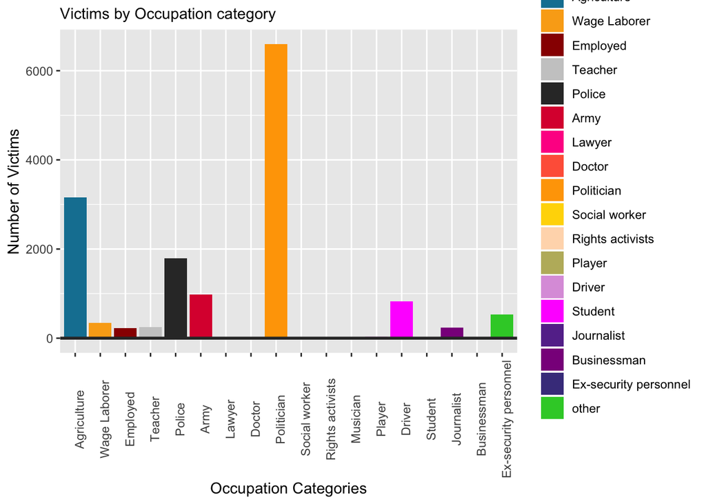

```r
OccupationCategoryLabels <- c("Agriculture", "Wage Laborer", "Employed", "Teacher", "Police", "Army", "Lawyer", "Doctor", "Politician", "Social worker", "Rights activists", "Musician", "Player", "Driver", "Student", "Journalist", "Businessman", "Ex-security personnel", "other")
# Bar Chart for plotting the number of victims as of Occupation category
 ggplot(victims_df, aes(x = factor(OccupationCategory), fill = factor(OccupationCategory))) +
    geom_bar(stat="count", position="dodge") +
    geom_hline(yintercept = 0, size = 1, colour="#333333") +
    scale_fill_manual(values = c("#1380A1", "#FAAB18", "#990000", "#cbcbcb","#333333", "#DC143C", "#FF1493", "#FF6347", "#FFA500", "#FFD700", "#FFDAB9", "#BDB76B", "#DDA0DD", "#FF00FF", "#663399", "#8B008B", "#483D8B", "#32CD32", "#2E8B57"),
                    name="Occupation Category",
                    breaks=c(1, 2, 3, 4, 5, 6, 7, 8, 9, 10, 11, 12, 13, 14, 15, 16, 17, 18, 19),
                    labels=OccupationCategoryLabels) +
  labs(subtitle="Victims by Occupation category") +
  scale_x_discrete(labels = OccupationCategoryLabels) +
  ylab('Number of Victims') +
  xlab('Occupation Categories') +
  theme(axis.text.x = element_text(angle = 90)
)
```

From the bar chart above, It is clear that the maximum number of the victims belonged to politician occupation category.

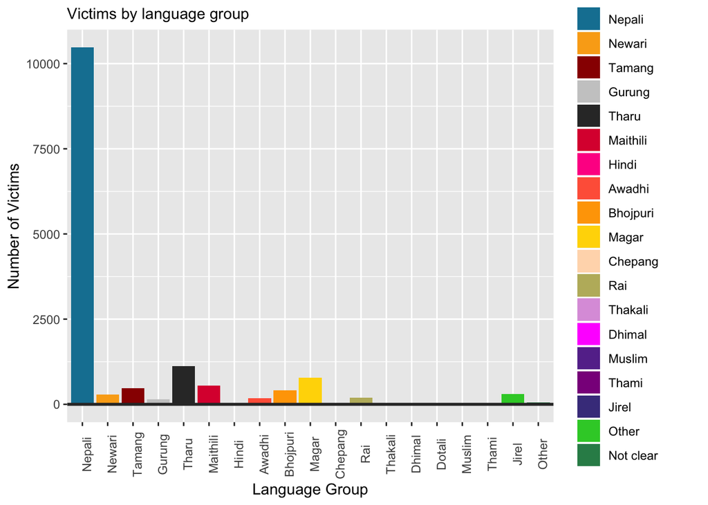

```r
LanguageGroupLabels <- c("Nepali", "Newari", "Tamang", "Gurung", "Tharu", "Maithili", "Hindi", "Awadhi", "Bhojpuri", "Magar", "Chepang", "Rai", "Thakali", "Dhimal", "Dotali", "Muslim", "Thami", "Jirel", "Other", "Not clear")
# Bar Chart for plotting the number of victims as of Language Group
 ggplot(victims_df, aes(x = factor(LanguageGroup), fill = factor(LanguageGroup))) +
  geom_bar(stat="count", position="dodge") +
  geom_hline(yintercept = 0, size = 1, colour="#333333") +
  scale_fill_manual(values = c("#1380A1", "#FAAB18", "#990000", "#cbcbcb","#333333", "#DC143C", "#FF1493", "#FF6347", "#FFA500", "#FFD700", "#FFDAB9", "#BDB76B", "#DDA0DD", "#FF00FF", "#663399", "#8B008B", "#483D8B", "#32CD32", "#2E8B57", "#556B2F"),
                    name="Language Group",
                    breaks=c(1, 2, 3, 4, 5, 6, 7, 8, 9, 10, 11, 12, 13, 14, 15, 16, 17, 18, 19, 20),
                    labels=LanguageGroupLabels) +
  labs(subtitle="Victims by language group") +
  scale_x_discrete(labels = LanguageGroupLabels) +
  ylab('Number of Victims') +
  xlab('Language Group') +
  theme(axis.text.x = element_text(angle = 90)
)
```

From the bar chart above, It is clear that the maximum number of the victims belonged to Nepali language speaking group.

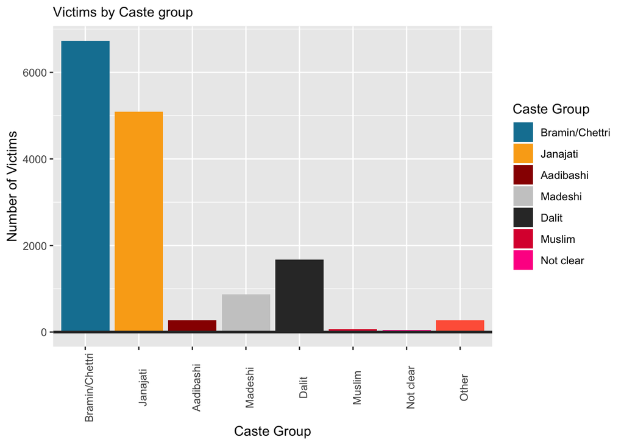

```r
CasteGroupLabels <- c("Bramin/Chettri", "Janajati", "Aadibashi", "Madeshi", "Dalit", "Muslim", "Not clear", "Other")
# Bar Chart for plotting the number of victims as of caste Group
 ggplot(victims_df, aes(x = factor(CasteGroup), fill = factor(CasteGroup))) +
  geom_bar(stat="count", position="dodge") +
  geom_hline(yintercept = 0, size = 1, colour="#333333") +
  scale_fill_manual(values = c("#1380A1", "#FAAB18", "#990000", "#cbcbcb","#333333", "#DC143C", "#FF1493", "#FF6347"),
                    name="Caste Group",
                    breaks=c(1, 2, 3, 4, 5, 6, 7, 8),
                    labels=CasteGroupLabels) +
  labs(subtitle="Victims by Caste group") +
  scale_x_discrete(labels = CasteGroupLabels) +
  ylab('Number of Victims') +
  xlab('Caste Group') +
  theme(axis.text.x = element_text(angle = 90)
)
```

From the bar chart above, It is clear that the maximum number of the victims belonged to Brahmin/Chettry caste group.

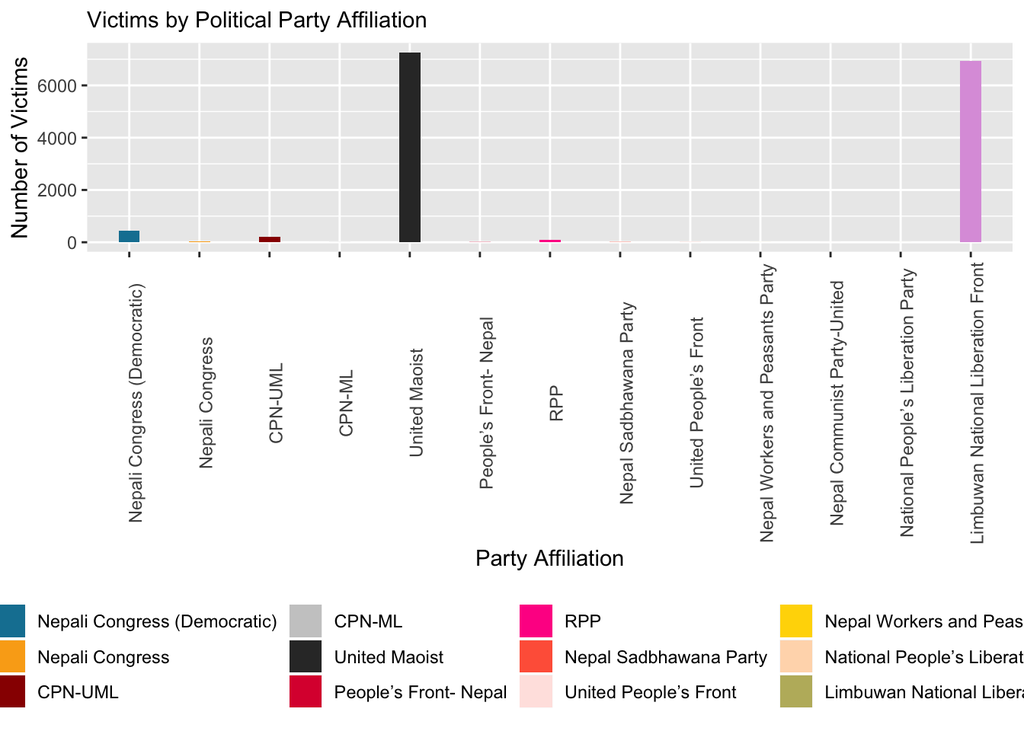

```r
PartyAffiliationLabels <- c("Nepali Congress (Democratic)", "Nepali Congress", "CPN-UML", "CPN-ML", "United Maoist", "People’s Front- Nepal", "RPP", "Nepal Sadbhawana Party", "United People’s Front", "Nepal Workers and Peasants Party", "Nepal Communist Party-United", "National People’s Liberation Party", "Limbuwan National Liberation Front", "Not identified")
# Bar Chart for plotting the number of victims as of party affiliation
 ggplot(victims_df, aes(x = as.factor(Partyaffiliation), fill = as.factor(Partyaffiliation))) +
  geom_bar(stat="count", position="dodge", width = 0.3) +
  scale_fill_manual(values = c("#1380A1", "#FAAB18", "#990000", "#cbcbcb","#333333", "#DC143C", "#FF1493", "#FF6347", "#FFE4E1", "#FFD700", "#FFDAB9", "#BDB76B", "#DDA0DD", "#DAA520"),
                    name="Party Affiliation",
                    breaks=c(1, 2, 3, 4, 5, 6, 7, 8, 9, 10, 11, 12, 13, 99),
                    labels=PartyAffiliationLabels) +
  labs(subtitle="Victims by Political Party Affiliation") +
  scale_x_discrete(labels = PartyAffiliationLabels) +
  ylab('Number of Victims') +
  xlab('Party Affiliation') +
  theme(axis.text.x = element_text(angle = 90), legend.position="bottom")
```

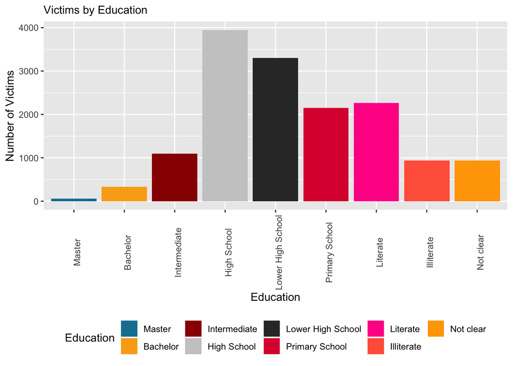

```r
EducationLabels <- c("Master", "Bachelor", "Intermediate", "High School", "Lower High School", "Primary School", "Literate", "Illiterate", "Not clear")
# Bar Chart for plotting the number of victims as of party affiliation
 ggplot(victims_df, aes(x = factor(Education), fill = factor(Education))) +
  geom_bar(stat="count", position="dodge") +
  scale_fill_manual(values = c("#1380A1", "#FAAB18", "#990000", "#cbcbcb","#333333", "#DC143C", "#FF1493", "#FF6347", "#FFA500"),
                    name="Education",
                    breaks=c(1, 2, 3, 4, 5, 6, 7, 8, 9),
                    labels=EducationLabels) +
  labs(subtitle="Victims by Education") +
  scale_x_discrete(labels = EducationLabels) +
  ylab('Number of Victims') +
  xlab('Education') +
  theme(axis.text.x = element_text(angle = 90), legend.position="bottom")
```